# gibbonsecr manual v0.0

3 April 2016

# 1 Overview

The `gibbonsecr` software package uses **Spatially Explicit Capture–Recapture (SECR)** methods to estimate the density of gibbon groups from acoustic survey data. This manual begins with a brief introduction to the theory behind SECR and then describes the main components of the user interface.

# 2 Introduction to SECR

Over the past decade SECR has become an increasingly popular tool for wildlife population assessment and has been used to analyse survey data for a wide range of animal groups. The main advantage of this method over traditional capture-recapture techniques is that it allows direct estimation of population **density** rather than abundance. Traditional capture-recapture methods can only provide density estimates through the use of separate estimates or assumptions about the size of the sampled area. In SECR however, density is estimated directly from the survey data by using information contained in the pattern of the recaptures to make inferences about the spatial location of animals. By extracting spatial information in this way, SECR provides estimates of density without requiring the exact locations of the detected animals to be known in advance.

## 2.1 Basic setup

The basic data collection setup for an SECR analysis consists of a spatial array of **detectors**. Detectors come in a variety of different forms, including traps which physically detain the animals, and **proximity detectors** which do not. The use of proximity detectors makes it possible for an animal to be detected at more than one detector (i.e. *recaptured*) during a single sampling occasion.

The plot below shows a hypothetical array of proximity detectors, with red squares representing detections of the same animal (or the same group in the case of gibbon surveys) and black squares representing no detections.

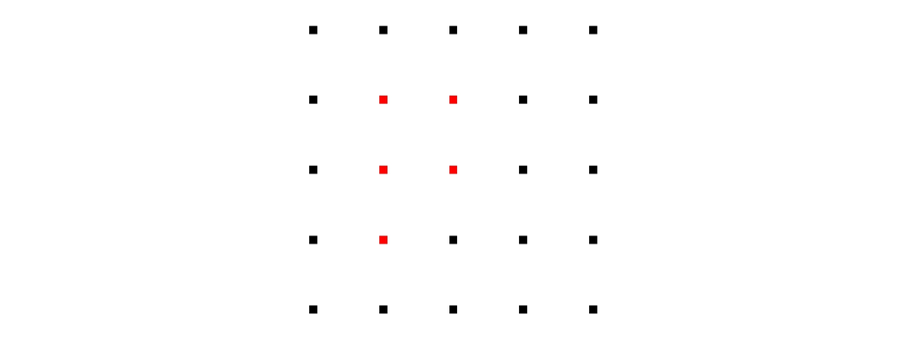

The pattern of the detections (i.e. the pattern of the recapture data) contains information about the true location of the animal/group; an intuitive guess would be that the true location is somewhere near the cluster of red detectors. The plot below shows a set of probability contours for this unknown location, given the recapture data.

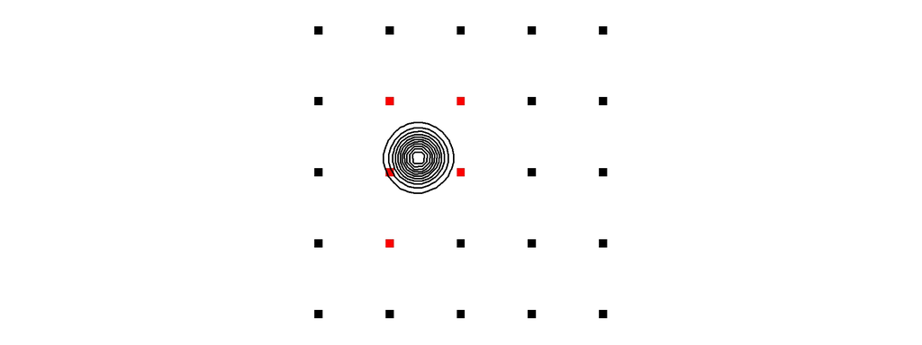

In the case of acoustic gibbon surveys the listening posts can be treated as proximity detectors and the same logic can be applied to obtain information on the locations of the detected groups. However, the design shown in the figure above would obviously be impractical for gibbon surveys. The next figure shows probability contours for a more realistic array of listening posts where a group has been detected at two of the posts.

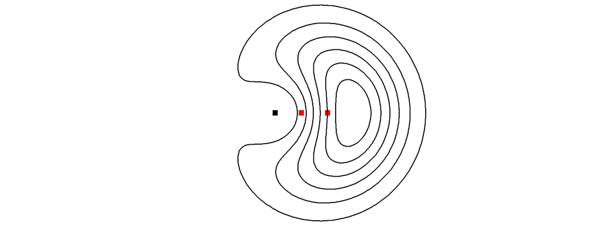

The obvious conclusion here is that using smaller arrays of detectors results in less information about the unknown locations.

## 2.2 Estimated bearings

SECR also allows **supplementary information** on group location to be included in the analysis in addition to the recapture data, for example in the form of **estimated bearings** to the detected animals/groups. The next figure illustrates how taking account of information contained in the estimated bearings can provide better quality information on unknown locations.

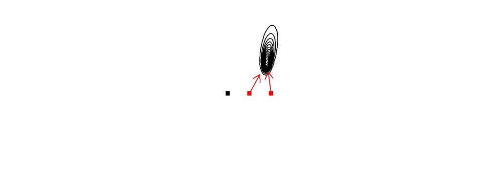

Using estimated bearings in this way can lead to density estimates that are less biased and more precise than using recapture data alone. Since the precision of bearing estimates is usually unknown, SECR methods need to estimate it from the data. This requires the choice of a **bearing error distribution**. The figure below shows two common choices of distribution for modelling bearing errors – the **von Mises** and the **wrapped Cauchy**. The colour of the lines in these plots indicate the value of the precision parameter (and which SECR estimates from the survey data).

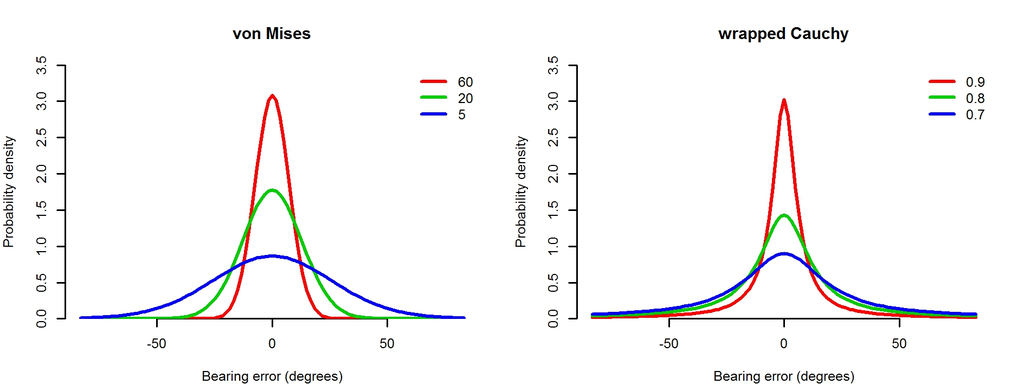

## 2.6 Effective sampling area

# 3 Loading the software

## 3.2 Launch from a desktop icon

### 3.2.2 Make a shortcut icon

# 4 Data import

## 4.3 Data buttons

# 5 Making a mask

## 5.3 Mask buttons

# 6 Model fitting

## 6.3 Model buttons

# 7 Plotting results

# 8 Model selection

## 8.2 Model plausibility

# 9 Menu Options

## 9.2 The Workspace menu

### 9.2.2 Saving and loading workspaces

# 10 Reporting bugs